# E-News Express A/B Testing Analysis

### Statistical Analysis Report

📘 Table of Content

1. Introduction
2. Problem Statement
3. Data Overview
4. Exploratory Data Analysis
   - Univariate Analysis
   - Bivariate Analysis
5. Hypothesis Testing
   - Q1. Time Spent Comparison (T-Test)
   - Q2. Conversion Rate Comparison (Z-Test)
   - Q3. Conversion vs Language (Chi-Square Test)
   - Q4. Time Spent vs Language (ANOVA)
6. Key Insights
7. Conclusion & Business Recommendation
8. Executive Summary

## 1. Introduction

E-news Express is an online news portal that aims to increase its subscriber base by improving user engagement on its website. The company has designed a new landing page with an updated layout and more relevant content to encourage users to subscribe to the platform. To evaluate the effectiveness of the new landing page, an A/B testing experiment was conducted in which users were randomly assigned to either the existing landing page (control group) or the new landing page (treatment group).

The goal of this analysis is to examine user behavior on both versions of the landing page and determine whether the new design leads to higher engagement and improved conversion rates. Statistical hypothesis testing is used to analyze the data and draw conclusions about the effectiveness of the new landing page.

## 2. Problem Statement

### 🔹Business Problem

E-news Express aims to improve online subscription by redesinging its landing page. The objective of this analysis is to evaluate whether the new landing page improves user engagement (time spent on page) and conversion rate compared to the existing page.

The analysis is conducted at a 5% significance level using hypothesis testing methods.

### 🔹Questions to Answer

The analysis aims to answer the following business questions:

1. Do users spend more time on the new landing page compared to the existing landing page?
2. Is the conversion rate higher for the new landing page than the old landing page?
3. Does the conversion status depend on the preferred language of users?
4. Is the mean time spent on the new landing page the same across different language users?

## 3. Data Overview

### 🔹Data Description

| column_name | description |
| --- | --- |
| user_id | Unique visitor |
| group | control vs treatment |
| landing_page | new vs old |
| time_spent_on_the_page | Time (in minutes) |
| converted | become subscriber (yes/no) |
| language_preferred | language |

### 🔹 Initial Checks

```python
#Importing common libraries
import numpy as np
import matplotlib.pyplot as plt
import pandas as pd
import seaborn as sns
import warnings
warnings.filterwarnings('ignore')
```

```python
# Loading the dataset
original_data = pd.read_csv('dataset/abtest.csv')
```

```python
df = original_data.copy()
```

```python
# Displaying the first 5 rows of the dataset
df.head()
```

|  | user_id | group | landing_page | time_spent_on_the_page | converted | language_preferred |
| --- | --- | --- | --- | --- | --- | --- |
| 0 | 546592 | control | old | 3.48 | no | Spanish |
| 1 | 546468 | treatment | new | 7.13 | yes | English |
| 2 | 546462 | treatment | new | 4.40 | no | Spanish |
| 3 | 546567 | control | old | 3.02 | no | French |
| 4 | 546459 | treatment | new | 4.75 | yes | Spanish |

```python
df.shape
```

```
(100, 6)
```

There are `100 rows` and `6 columns` in the dataset.

So the dataset contains `100 observations` having `6 variables`.

```python
# Displaying the summary of the dataset
df.info()
```

```
<class 'pandas.core.frame.DataFrame'>
RangeIndex: 100 entries, 0 to 99
Data columns (total 6 columns):
 #   Column                  Non-Null Count  Dtype
---  ------                  --------------  -----
 0   user_id                 100 non-null    int64
 1   group                   100 non-null    object
 2   landing_page            100 non-null    object
 3   time_spent_on_the_page  100 non-null    float64
 4   converted               100 non-null    object
 5   language_preferred      100 non-null    object
dtypes: float64(1), int64(1), object(4)
memory usage: 4.8+ KB
```

The dataset consists of one numerical variable (time_spent_on_the_page) and multiple categorical variables.

```python
# Displaying the statistical summary of the dataset
df.describe()
```

|  | user_id | time_spent_on_the_page |
| --- | --- | --- |
| count | 100.000000 | 100.000000 |
| mean | 546517.000000 | 5.377800 |
| std | 52.295779 | 2.378166 |
| min | 546443.000000 | 0.190000 |
| 25% | 546467.750000 | 3.880000 |
| 50% | 546492.500000 | 5.415000 |
| 75% | 546567.250000 | 7.022500 |
| max | 546592.000000 | 10.710000 |

The summary statistics show the distribution of time spent on the landing page.  
The variation indicates differences in user engagement levels across users.

```python
# Checking for missing values in the dataset
df.isna().sum()
```

```
user_id                   0
group                     0
landing_page              0
time_spent_on_the_page    0
converted                 0
language_preferred        0
dtype: int64
```

There are no missing values in the dataset, indicating that the data is complete for analysis.

```python
# Checking for duplicate values in the dataset
df.duplicated().sum()
```

```
np.int64(0)
```

No duplicate records are present in the dataset.

```python
df['group'].value_counts()
```

```
group
control      50
treatment    50
Name: count, dtype: int64
```

> The balanced structure between control and treatment groups supports valid A/B testing assumptions.

## 4. Exploratory Data Analysis (EDA)

### 🔹Univariate Analysis

#### Categorical :

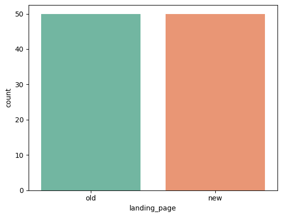

```python
# Visualizing the distribution of the landing_page variable
sns.countplot(data=df,
              x='landing_page',
              order=df['landing_page'].value_counts().index.tolist(),
              palette='Set2')
```

**Landing Page Distribution**

The bar chart above visualizes the distribution of users across the two landing page variants (old vs. new). Both variants have an equal count of **50 users**, indicating a perfectly balanced A/B test design. This equal distribution suggests that the difference in the user engagement or conversions is due to the landing page design itself and not due to the imbalance in the number of observations. This is critical measure for the hypothesis testing results.

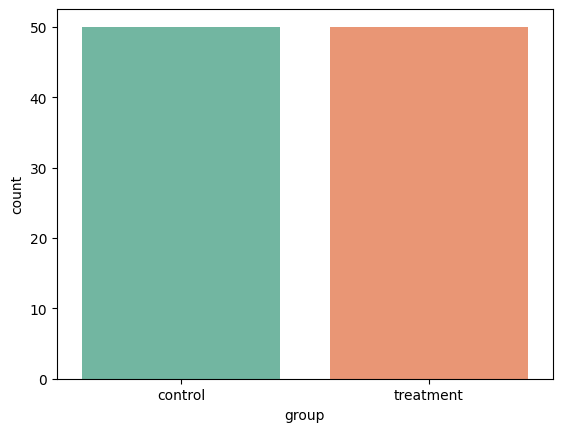

```python
# Visualizing the distribution of the group variable
sns.countplot(data=df,
              x='group',
              palette='Set2')
```

**Control vs Treatment Group Distribution**

The bar chart above shows the distribution of users across the control and treatment groups. Both groups contain **50 users**, demonstrating a balanced experimental design. The control group was provided with the old landing page while treatment group has been provided a experience with the new landing page. The equal distribution ensures that any difference observed between the groups is due to the landing page difference, which maintains the integrety of the A/B test.

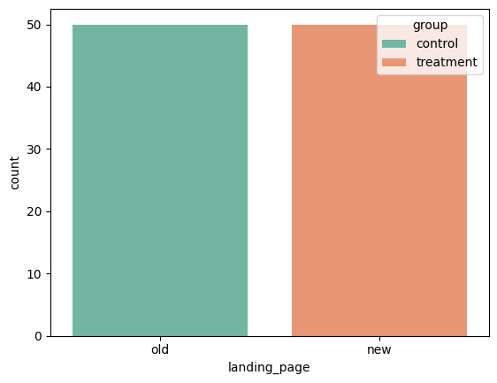

```python
#visualizing the distribution of the landing page variable
sns.countplot(data=df,
              x='landing_page',
              hue='group',
              palette='Set2')
```

Landing Page Distribution by Group

This visualization shows the interaction between landing page variants and experimental groups. The chart reveals:

- **Old Landing Page**: 50 users
- **New Landing Page**: 50 users

The balanced distribution across both conditions is crucial for A/B testing validity. Each group has exactly 50 observations, ensuring that any differences in engagement or conversion metrics can be confidently attributed to the landing page design rather than sample size imbalances or selection bias.

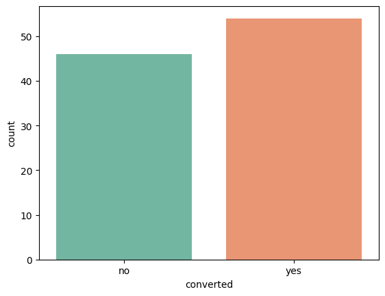

```python
#visualizing the distribution of the converted variable
sns.countplot(data=df,
              x='converted',
              palette='Set2')
```

**Conversion Status Distribution**

This bar chart displays the overall conversion rate in the dataset:

- **Conversion Breakdown**: The chart shows the count of users who converted (became subscribers) versus those who did not
- **Class Imbalance**: There is an imbalance in the distribution, with more converted users than non-converted users
- **Overall Rate**: This gives us a baseline understanding of the conversion rate before segmenting by landing page or other factors

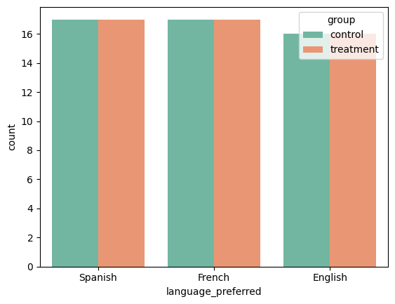

```python
#visualizing the distribution of the language_preferred variable
sns.countplot(data=df,
              x='language_preferred',
              order=df['language_preferred'].value_counts().index.tolist(),
              palette='Set2',
              hue='group',
              hue_order=df['group'].value_counts().index.tolist())
```

Language distribution appears reasonably balanced across categories.

#### Numerical:

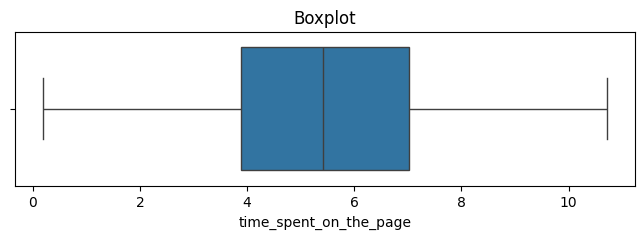

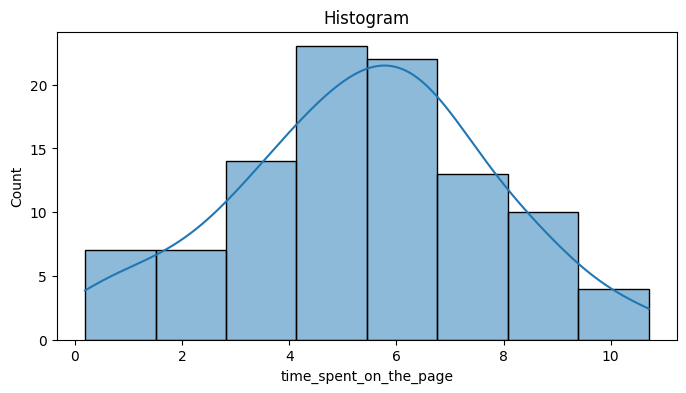

```python
# Figure 1: boxplot
fig1, ax1 = plt.subplots(figsize=(8,2))
sns.boxplot(x=df['time_spent_on_the_page'], ax=ax1, color="C0")
ax1.set_title("Boxplot")

# Figure 2: histogram
fig2, ax2 = plt.subplots(figsize=(8,4))
sns.histplot(df['time_spent_on_the_page'], ax=ax2, kde=True, color="C0")
ax2.set_ylabel("Count")
ax2.set_title("Histogram")

plt.show()
```

### 🔹Bivariate Analysis

##### 🔹Landing Page Vs Time Spent

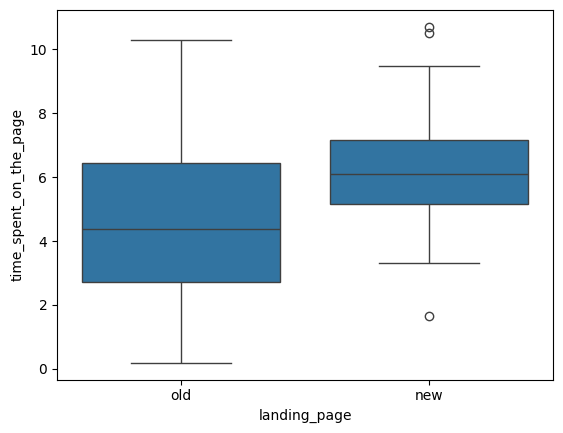

```python
# Visualizing the relationship between landing_page and time_spent_on_the_page
sns.boxplot(data=df, x='landing_page', y='time_spent_on_the_page')
```

**Time Spent on Landing Page by Landing Page Variant**

This boxplot compares user engagement (time spent on page) between the old and new landing page variants:

This visual comparison suggests that the new landing page may be more effective at retaining user attention, which can lead to higher subscription conversion rates.

##### 🔹Landing Page vs Converted

[figure not shown]

```python
# Visualizing the relationship between landing_page and converted
sns.barplot(data=df, x='landing_page', y='converted')
```

- **New Page Performance**: The new landing page shows a visibly higher average conversion rate
- **Old Page Baseline**: The old page serves as the baseline control condition
- **Difference Magnitude**: The difference between the two charts suggests that there is an improvement in conversion with the new design

This suggests that the hypothesis that the new landing page design leads to higher user conversion rates, which will be tested statistically in the hypothesis testing section.

##### 🔹Language Vs Time spent

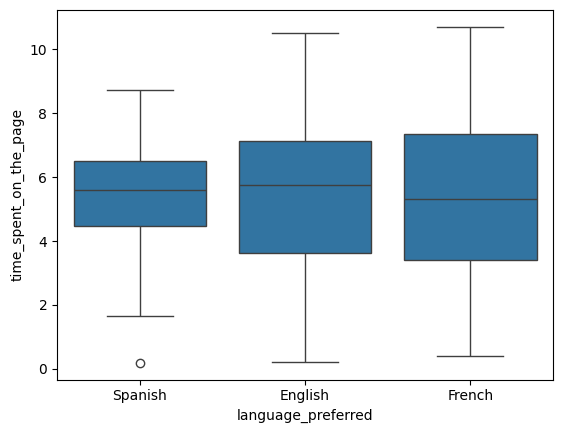

```python
# Visualizing the relationship between language_preferred and time_spent_on_the_page
sns.boxplot(data=df, x='language_preferred', y='time_spent_on_the_page')
```

This visual suggests that language preference alone is not a strong predictor of user engagement duration on the landing page.

##### 🔹Language Vs Converted

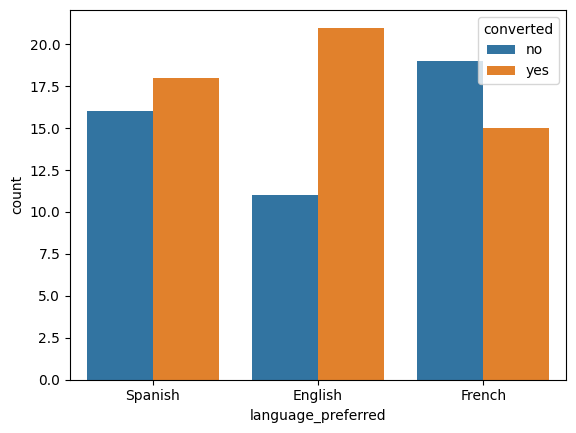

```python
# Visualizing the relationship between language_preferred and converted
sns.countplot(data=df, x='language_preferred', hue='converted')
```

## 5. Hypothesis Testing

#### **Q1: Do users spend more time on the new landing page?**

##### Visual Depiction from EDA

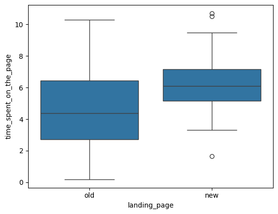

**Interpretation** Visual inspection of the boxplot indicates that users interacting with the new landing page appear to spend slightly more time compared to those interacting with the old landing page. However, visual differences alone cannot confirm statistical significance, therefore hypothesis testing is required.

##### Hypothesis

**Null Hypothesis(H0):** The mean time spent on the new landing page is less than or equal to the mean time spent on the old landing page.

> H0 : $\mu_\text{new}$ $\le$ $\mu_\text{old}$

**Alternative Hypothesis(H1):** The mean time spent on the new landing page is greater than the mean time spent on the old landing page.

> H1 : $\mu_\text{new}$ $\gt$ $\mu_\text{old}$

This is `one-tailed test` because we are looking for *greater than condition*.

##### Test Selection

> Independent Samples t-test is appropriate because
> - Comparing means of two independent group
> - Numeric dependent variable
> - Random assignment ensures independence

##### Data Preparation

The dataset is divided into two groups based on the landing page shown to users.  
The time spent on the old landing page and the new landing page is extracted separately in order to compare the average time spent by users.

```python
#Data Preparation

old = df[df['landing_page']=='old']['time_spent_on_the_page']
new = df[df['landing_page']=='new']['time_spent_on_the_page']
```

```python
from scipy.stats import ttest_ind

t_stat, p_value = ttest_ind(new, old, alternative='greater', equal_var=False)
```

```python
#Levene test
from scipy.stats import levene

l_stats, l_p_value = levene(new, old)
```

```python
print(f"Levene test statistic: {l_stats}, p_value: {l_p_value}")
```

```
Levene test statistic: 7.113724153407544, p_value: 0.008950671168914445
```

Levene’s test was conducted to assess the equality of variances between the two groups. The p-value obtained (0.0089) is less than the significance level of 0.05, indicating that the variances are significantly different. Therefore, the equal variance assumption does not hold and Welch’s t-test is used.

```python
print (f"T-statistic: {t_stat}, P-value: {p_value}")
```

```
T-statistic: 3.7867702694199856, P-value: 0.0001392381225166549
```

#### Inference

**Significance level** ($\alpha$) = 0.05

**Decision Rule:** Reject the null hypothesis if p-value < 0.05.

T-statistics = 3.78  
p-value = 0..00013

Since the p-value (0.00013) is less than the significance level of 0.05, we reject the null hypothesis and conclude that users spend significantly more time on the new landing page compared to the old landing page.

#### **Q2: Is conversion rate higher for new page?**

##### **Visual Depiction from EDA**

[figure not shown]

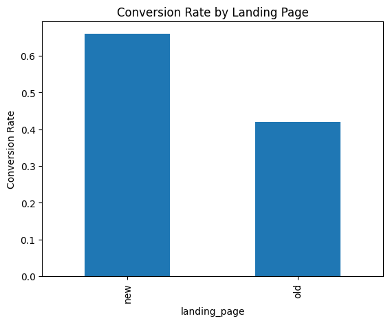

```python
conversion_rate = df.groupby('landing_page')['converted'].apply(lambda x: (x == 'yes').mean())

conversion_rate.plot(kind='bar')
plt.title("Conversion Rate by Landing Page")
plt.ylabel("Conversion Rate")
plt.show()
```

The bar chart suggests that the conversion rate for the new landing page appears higher than that of the old landing page. However, visual differences alone cannot confirm statistical significance, therefore a hypothesis test is required.

#### **Hypothesis**

**Null Hypothesis ($H_0$):** The conversion rate of the new landing page is less than or equal to the conversion rate of the old landing page.

> $H_0$ : $p_{new}$ $\le$ $p_{old}$

Alternative Hypothesis ($H_1$): The conversion rate of the new landing page is greater than the conversion rate of the old landing page.

> $H_1$ : $p_{new}$ $\gt$ $p_{old}$

This is `one-tailed` test.

A Two-Proportion Z-test is appropriate because we are comparing the proportions of a binary outcome (conversion vs no conversion) between two independent groups (old landing page and new landing page).

```python
from statsmodels.stats.proportion import proportions_ztest
```

##### Data Preparation

The number of converted and non-converted users for both landing pages is calculated.  
These counts are used to compute the conversion proportions for the z-test for proportions.

```python
# Count conversions per landing page
conversion_counts = df.groupby('landing_page')['converted'].apply(lambda x: (x == 'yes').sum())
total_counts = df.groupby('landing_page')['converted'].count()
```

The number of successful conversions and total users for each landing page were extracted to compute the conversion proportions.

```python
# Perform one-tailed Z-test (new > old)
z_stat, p_value = proportions_ztest(
    conversion_counts,
    total_counts,
    alternative='larger'
)
```

```python
print("Two-Proportion Z-Test")
print("Z-statistic:", z_stat)
print("P-value:", p_value)
```

```
Two-Proportion Z-Test
Z-statistic: 2.4077170617153842
P-value: 0.008026308204056278
```

#### Inference

**Significance level** ($\alpha$) = 0.05  
**Decision Rule:** Reject the null hypothesis if p-value < 0.05.

z-statistics : 2.41  
p-value: 0.008

Since the p-value(0.008) is less than 0.05, we reject the null hypothesis and conclude that the conversion rate of the new landing page is significantly higher than the old landing page.

✅ Conclusion: The new page improves subscriber acquisition.

#### **Q3: Does conversion depend on language?**

##### 🔹 Visual Analysis

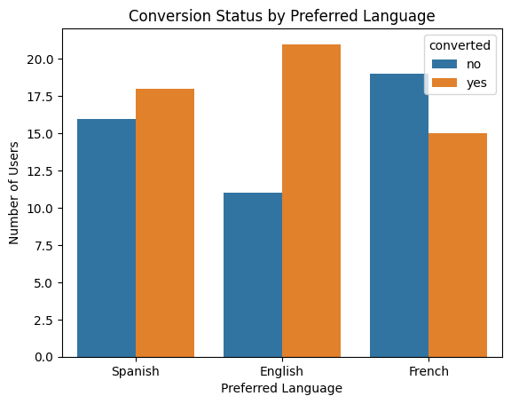

```python
sns.countplot(data=df, x='language_preferred', hue='converted')
plt.title("Conversion Status by Preferred Language")
plt.xlabel("Preferred Language")
plt.ylabel("Number of Users")
plt.show()
```

The plot shows the distribution of converted and non-converted users across different language groups. While some variation is visible across languages, the differences do not appear large. A statistical test is therefore required to determine whether conversion status is dependent on language preference.

##### **Hypothesis**

**Null Hypothesis ($H_0$):** Conversion status is independent of the preferred language.

> $H_0$: Conversion status and language preference are independent

**Alternative Hypothesis ($H_1$):** Conversion status depends on the preferred language.

> $H_1$: Conversion status and language preference are associated

A `Chi-Square test of Independence` is appropriate because both variables (conversion status and language preference) are categorical, and the test evaluates whether there is a statistically significant association between them.

```python
from scipy.stats import chi2_contingency
```

##### Data Preparation

A contingency table is created to summarize the number of converted and non-converted users across different language groups.  
This table is used as input for the Chi-square test of independence.

```python
#Data Preparation for chi-square test
contingency_table = pd.crosstab(df['language_preferred'], df['converted'])
```

```python
#Running the chi-square test
chi2_stat, p_value, dof, expected = chi2_contingency(contingency_table)
```

```python
print("Chi-Square Test of Independence")
print("Chi-square Statistic:", chi2_stat)
print("Degrees of Freedom:", dof)
print("P-value:", p_value)
```

```
Chi-Square Test of Independence
Chi-square Statistic: 3.0930306905370832
Degrees of Freedom: 2
P-value: 0.2129888748754345
```

#### Inference

**Significance level** ($\alpha$) = 0.05

**Decision Rule:** Reject the null hypothesis if p-value < 0.05.

chi-square statistics : 3.09  
p-value = 0.213

Since the p-value(0.213) is greater than 0.05, we fail to reject the null hypothesis, indicating that conversion status is independent of the preferred language.

🔭 **Observation:** This suggests that language preference does not significantly influence whether a user subscribes to the news portal.

✅ **Conclusion:** Conversion is independent of language.

#### **Q4: Is mean time spent same across languages?**

##### **Perform Visual Analysis**

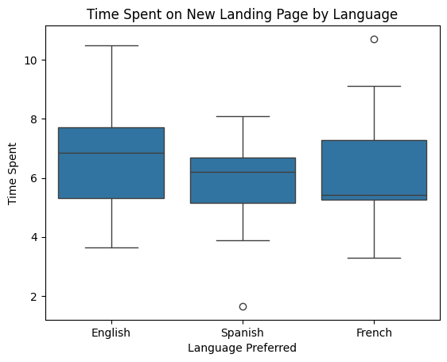

```python
# creating a new dataframe for new landing page
new_page_df = df[df['landing_page'] == 'new']

# Visualizing the relationship between language_preferred and time_spent_on_the_page for new landing page
sns.boxplot(data=new_page_df, x='language_preferred', y='time_spent_on_the_page')
plt.title("Time Spent on New Landing Page by Language")
plt.xlabel("Language Preferred")
plt.ylabel("Time Spent")
plt.show()
```

The boxplot compares engagement time across different language groups for users who interacted with the new landing page. The median engagement time appears relatively similar across languages. However, statistical testing is required to determine whether any observed differences are statistically significant.

The distribution of time spent appears similar across different language groups, suggesting that the average engagement time may not differ significantly.

##### **Hypothesis:**

**Null Hypothesis ($H_0$):** The mean time spent on the new landing page is the same for all language groups.

> $H_0$ : $\mu_\text{1}$ = $\mu_\text{2}$ = $\mu_\text{3}$

**Alternative Hypothesis ($H_1$):** At least one language group has a different mean time spent on the new landing page.

> $H_1$: Atleast one mean differs

A `One-Way ANOVA test` is appropriate because we are comparing the mean values of a continuous variable (time spent) across more than two independent categorical groups (language preferences).

```python
from scipy.stats import f_oneway
```

##### Data Preparation

The dataset is filtered to include only users who were shown the new landing page.  
The time spent values are grouped by preferred language to compare the mean engagement across language groups.

```python
#Data Preparation for ANOVA test
english = new_page_df[new_page_df['language_preferred'] == 'English']['time_spent_on_the_page']
spanish = new_page_df[new_page_df['language_preferred'] == 'Spanish']['time_spent_on_the_page']
french = new_page_df[new_page_df['language_preferred'] == 'French']['time_spent_on_the_page']
```

##### Calculate the p-value

```python
from scipy.stats import f_oneway

f_stat, p_value = f_oneway(english, spanish, french)

print("F-statistic:", f_stat)
print("P-value:", p_value)
```

```
F-statistic: 0.854399277000682
P-value: 0.43204138694325955
```

#### Inference

**Significance level** ($\alpha$) = 0.05

**Decision Rule:** Reject the null hypothesis if p-value < 0.05.

F-statistic: 0.85  
P-value: 0.432

Since the p-value(0.432) is greater than 0.05, we fail to reject the null hypothesis and conclude that the mean time spent on the new landing page does not significantly differ across language groups.

🔭 This suggests that engagement with the redesigned landing page is consistent across different language users.

✅ Conclusion: Engagement time does not vary by language.

## 6. Key Insights

### 🔹Key Insight from the Testing

- Users spend significantly more time on the new landing page, indicating improved engagement with the redesigned layout and content.
- The conversion rate for the new landing page is higher, suggesting that the updated page design is more effective in converting visitors into subscribers.
- Conversion behavior does not significantly depend on preferred language, indicating consistent user response across language groups.
- Time spent on the new landing page does not vary significantly across languages, suggesting that the page design performs uniformly for all users.
- Overall, the redesigned landing page improves both engagement and conversion performance, making it a better option for deployment.

## 7. Conclusion & Business Recommendation

### 🔹Conclusion

The analysis evaluated the effectiveness of the redesigned landing page through A/B testing using statistical hypothesis testing at a 5% significance level.

Key findings from the analysis include:

• Users spend significantly more time on the new landing page, indicating improved engagement.  
• The conversion rate for the new landing page is higher than the old page, demonstrating that the redesign positively impacts subscription behavior.  
• Conversion does not depend on the user's preferred language, meaning the platform performs consistently across language groups.  
• The time spent on the new landing page is similar across different languages, indicating that the design is equally effective for all language users.

Overall, the statistical evidence supports that the new landing page is more effective in engaging users and improving conversion outcomes.

### 🔹Business Recommendations

Based on the findings, the following recommendations are proposed:

1. **Deploy the new landing page across all users**  
   The new page significantly improves user engagement and conversion performance.
2. **Focus on engagement-driven design**  
   Features such as better content layout and improved visual hierarchy likely contributed to increased time spent on the page.
3. **Maintain multilingual consistency**  
   Since engagement does not significantly differ across language groups, the current multilingual design approach is effective.
4. **Continue A/B testing for optimization**  
   Future experiments can test additional features such as content personalization or recommendation sections.

## 8. Executive Summary

The redesigned landing page demonstrates statistically significant improvements in both user engagement and conversion performance. The primary performance driver is page design rather than language preference. Immediate deployment is recommended, supported by a structured experimentation strategy to sustain long-term growth.